# Class 12 OLS Regression Basics

Author

Affiliation

Dr Wei Miao

UCL School of Management

Published

November 8, 2023

# 1 Basics of Linear Regression

## 1.1 Linear Regression Models

- A simple linear regression is a model as follows.
  $$Y_i = \beta_0 + x_1 \beta_1 + x_2\beta_2+ \ldots + x_k\beta_k + \epsilon_i$$
- $y_i$: Outcome variable/dependent variable/regressand/response variable/LHS variable
- $\beta$: Regression coefficients/estimates/parameters; $\beta_0$: intercept
- $x_k$: Control variable/independent variable/regressor/explanatory variable/RHS variable
  - Lower case such as $x_1$ usually indicates a single variable while upper case such as $X_{ik}$ indicates a set of several variables
- $\epsilon_i$: Error term, which captures the deviation of Y from the prediction
  - Expected mean should be 0, i.e., $E[\epsilon|X]=0$
  - If we take the expectation of Y, we should have
    $$E[Y|X] = \beta_0 + x_1 \beta_1 + x_2\beta_2+ \ldots + x_k\beta_k$$

## 1.2 Why the Name “Regression”?

- The term “regression” was coined by Francis Galton to describe a biological phenomenon: The heights of descendants of tall ancestors tend to regress down towards a normal average.
- The term “regression” was later extended by statisticians Udny Yule and Karl Pearson to a more general statistical context (Pearson, 1903).
- In supervised learning models, “regression” has a different meaning: when outcome is continuous, the task is called regression task.[^1]

# 2 Estimation of Coefficients

## 2.1 How to Run Regression in R

- In R, there are tons of packages that can run OLS regression.
- In this module, we will be using the `fixest` package, because it’s able to estimate high-dimensional fixed effects.

```r
pacman::p_load(modelsummary,fixest)

OLS_result <- feols(
   fml = total_spending ~ Income, # Y ~ X
   data = data_full, # dataset from Tesco
   )
```

## 2.2 Report Regression Results

```r
modelsummary(OLS_result,
    stars = TRUE  # export statistical significance
  )
```

|  | (1) |
| --- | --- |
| (Intercept) | −552.235*** |
|  | (20.722) |
| Income | 0.021*** |
|  | (0.000) |
| Num.Obs. | 2000 |
| R2 | 0.630 |
| R2 Adj. | 0.630 |
| AIC | 29130.1 |
| BIC | 29141.3 |
| RMSE | 351.63 |
| Std.Errors | IID |

+ p < 0.1, * p < 0.05, ** p < 0.01, *** p < 0.001

## 2.3 Parameter Estimation: Univariate Regression Case

- Let’s take a **univariate regression**[^2] as an example

$$y = a + b x_1 + \epsilon$$

- For each guess of a and b, we can compute the error for customer $i$,
  $$e_i = y_{i}-a-b x_{1i}$$
- We can compute the **sum of squared residuals (SSR)** across all customers

$$SSR =\sum_{i=1}^{n}\left(y_{i}-a-b x_{1i}\right)^{2}$$

- **Objective of estimation**: Search for the unique set of $a$ and $b$ that can minimize the SSR.
- This estimation method that minimizes SSR is called **Ordinary Least Square (OLS).**

## 2.4 Visualization: Estimation of Univariate Regression

- If in the Tesco dataset, if we regress **total spending** (Y) on **income** (X)

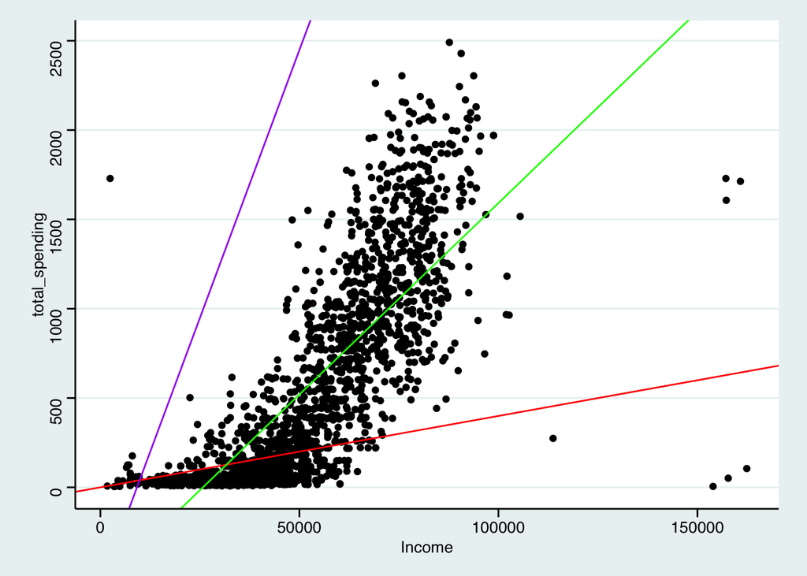

| Model | Color | Sum of Squared Error |
| --- | --- | --- |
| $Y = -552 + 0.06 * X$ | Purple | 1.6176047^{13} |
| $Y = 0 + 0.004 * X$ | Red | 5.093683^{11} |
| $Y = -552 + 0.021 * X$ | Green | 2.0205681^{9} |

## 2.5 Multivariate Regression

- The OLS estimation also applies to multivariate regression with multiple regressors.

$$y_i = b_0 + b_1 x_{1} + ... + b_k x_{k}+\epsilon_i$$

- **Objective of estimation**: Search for the **unique** set of $b$ that can minimize the **sum of squared residuals**.

$$SSR= \sum_{i=1}^{n}\left(y_{i}-b_0 - b_1 x_{1} - ... - b_k x_{k} \right)^{2}$$

# 3 Interpretation of Coefficients

## 3.1 Coefficients Interpretation

- Now on your Quarto document, let’s run a new regression, where the DV is $total\_spending$, and X includes $Income$ and $Kidhome$.

|  | (1) |
| --- | --- |
| (Intercept) | −316.878*** |
|  | (26.972) |
| Income | 0.019*** |
|  | (0.000) |
| Kidhome | −210.613*** |
|  | (16.282) |
| Num.Obs. | 2000 |
| R2 | 0.658 |
| R2 Adj. | 0.658 |
| AIC | 28971.2 |
| BIC | 28988.0 |
| RMSE | 337.77 |
| Std.Errors | IID |

+ p < 0.1, * p < 0.05, ** p < 0.01, *** p < 0.001

- **Controlling for** Kidhome, one unit increase in `Income` increases `totalspending` by £0.019.

## 3.2 Standard Errors and P-Values

- Because the regression is estimated on a random sample of the population, so if we rerun the regression on different samples, we would get a different set of regression coefficients each time.
- In theory, the regression coefficients estimates follows a **t-distribution**: the mean is the true $\beta$. The **standard error** of the estimates is the estimated standard deviation of the error.
- We can test whether the coefficients are statistically different from 0 using **hypothesis testing**.
  - Null hypothesis: the true regression coefficient $\beta$ is 0
- `Income`/`Kidhome` is statistically significant at the 1% level.

## 3.3 R-Squared

- R-squared (R2) is a statistical measure that represents the proportion of the variance for a dependent variable that’s explained by all included variables in a regression.
- Interpretation: 65.8% of the variation in `totalspending` can be explained by `Income` and `Kidhome`.
- As the number of variables increases, the $R^2$ will naturally increase, so sometimes we may need to penalize the number of variables using the so-called **adjusted R-squared**.

  **Important**

  R-Squared is only important for supervised learning prediction tasks, because it measures the predictive power of the X. However, In causal inference tasks, $R^2$ does not matter much.

## Footnotes

[^1]: ML models are developed by computer science; causal inference models are developed by economists.
[^2]: Regressions with a single regressor is called univariate regressions.